# **Author : Süleyman Emre Parlak**

## **1. (3p) Data:**

Please find your original dataset or datasets; and describe your data in the first step.  
(3-5 sentences)

```r
options(width = 10000)
data <- read.csv("Data.csv")
```

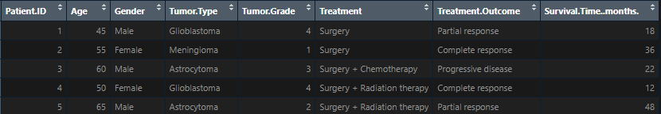

The dataset summarizes patient demographics, tumor characteristics, treatment details, and outcomes. It encompasses age, gender, tumor type and grade, treatment modalities, and survival time in months. This information offers insights into brain tumor patient profiles, treatments, and their effects on survival.

## 2. (3p) Exploratory and descriptive data analysis:

**Use “Exploratory and descriptive data analysis”. Talk about your categorical andquantitative data or your ordinal variables etc. Write down your comments. (3-4sentences)**

## 3.(4p) Data Visualization:

**Use 2 useful, meaningful and different “data visualization techniques” which will help you understand your data further (distribution, outliers, variability, etc). And use another 2 visualizations to compare two groups (like female/male; smoker/nonsmoker etc). For each visualization, write down your comments. (2-3 sentences each)**

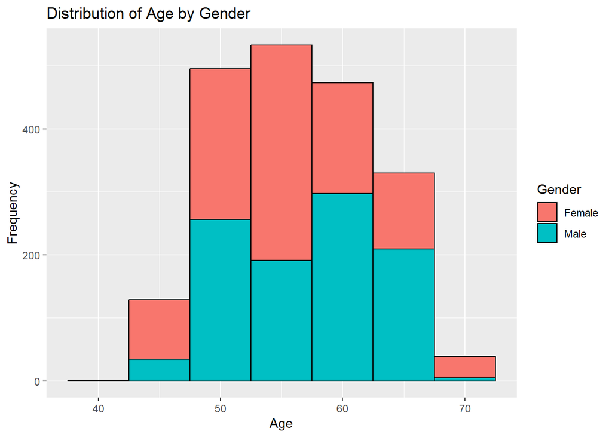

```r
library(ggplot2)
ggplot(data = data, aes(x = Age, fill = Gender)) +
  geom_histogram(binwidth = 5, color = "black") +
  labs(title = "Distribution of Age by Gender",
       x = "Age",
       y = "Frequency",
       fill = "Gender")
```

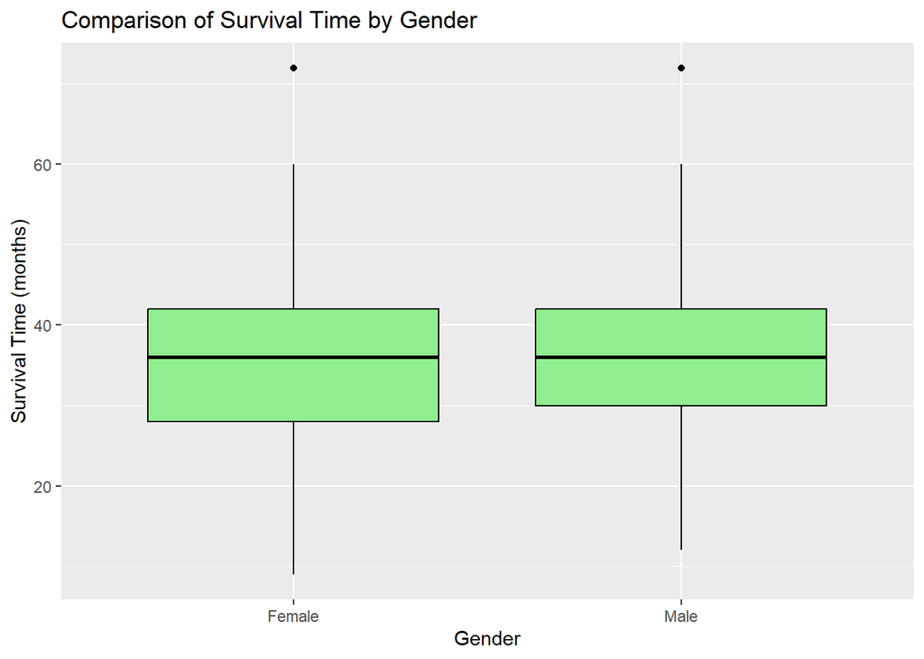

```r
ggplot(data = data, aes(x = Gender, y = Survival.Time..months.)) +
  geom_boxplot(fill = "lightgreen", color = "black") +
  labs(title = "Comparison of Survival Time by Gender",
       x = "Gender",
       y = "Survival Time (months)")
```

Apparently, there isn’t much difference when comparing gender to survival time.

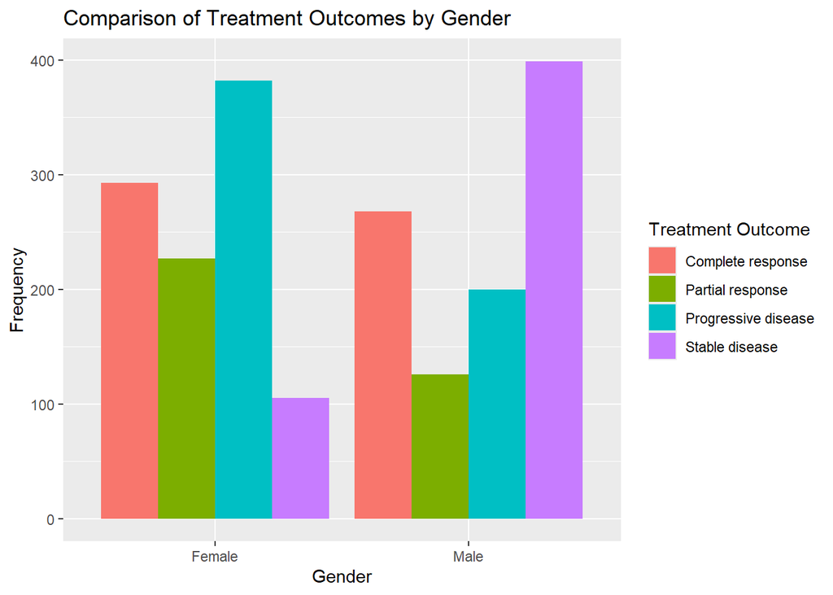

```r
ggplot(data = data, aes(x = Gender, fill = Treatment.Outcome)) +
  geom_bar(position = "dodge") +
  labs(title = "Comparison of Treatment Outcomes by Gender",
       x = "Gender",
       y = "Frequency",
       fill = "Treatment Outcome")
```

It seems very clear that progressive disease is much more common in women, while stable disease is more common in men. The ratios of Complete response and Partial response values are partially the same.

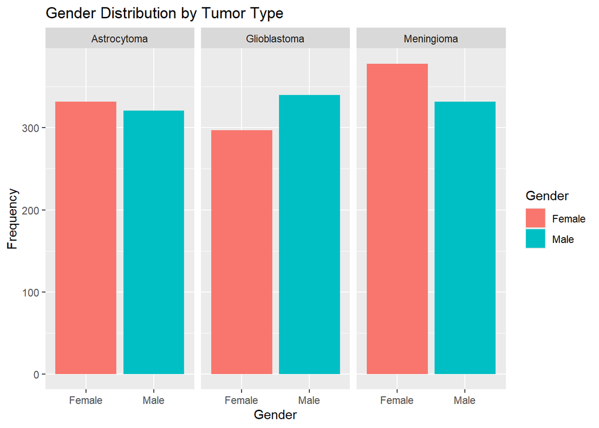

```r
ggplot(data = data, aes(x = Gender, fill = Gender)) +
  facet_wrap(~Tumor.Type) +
  geom_bar() +
  labs(title = "Gender Distribution by Tumor Type",
       x = "Gender",
       y = "Frequency",
       fill = "Gender")
```

No significant difference was seen when tumor types and gender were compared.

## 4.(4p) Confidence Intervals:

**Build ‘2 Confidence Intervals’ step by step: a) Calculate the mean, then b) standard error, and then c) the CI. Make “clear comments” about your findings in a, b and c.**

```r
mean_survival <- mean(data$Survival.Time..months.)
mean_survival
```

```
## [1] 34.27
```

```r
sd_survival <- sd(data$Survival.Time..months.)
se_survival <- sd_survival / sqrt(nrow(data))
se_survival
```

```
## [1] 0.1924437
```

```r
confidence_level <- 0.95
z_value <- qnorm((1 + confidence_level) / 2)

lower_bound <- mean_survival - z_value * se_survival
upper_bound <- mean_survival + z_value * se_survival

c(lower_bound, upper_bound)
```

```
## [1] 33.89282 34.64718
```

1. The mean survival time for the dataset is 34.27 months. This represents the average duration that patients in the study survived after treatment.
2. The standard error of the mean is 0.1924. This value indicates the level of accuracy of the mean survival time. A smaller standard error suggests that the sample mean is a more precise estimate of the population mean.
3. The 95% confidence interval for the mean survival time is [33.89, 34.65] months. This interval suggests that we can be 95% confident that the true mean survival time for the population lies within this range.

```r
glioblastoma_data <- data[data$Tumor.Type == "Glioblastoma", ]
mean_glioblastoma_survival <- mean(glioblastoma_data$Survival.Time..months.)
mean_glioblastoma_survival
```

```
## [1] 31.5259
```

```r
sd_glioblastoma_survival <- sd(glioblastoma_data$Survival.Time..months)
se_glioblastoma_survival <- sd_glioblastoma_survival / sqrt(nrow(glioblastoma_data))
se_glioblastoma_survival
```

```
## [1] 0.2522316
```

```r
lower_bound_glioblastoma <- mean_glioblastoma_survival - z_value * se_glioblastoma_survival
upper_bound_glioblastoma <- mean_glioblastoma_survival + z_value * se_glioblastoma_survival

c(lower_bound_glioblastoma, upper_bound_glioblastoma)
```

```
## [1] 31.03154 32.02027
```

1. The mean survival time for patients with glioblastoma is 31.53 months. This represents the average duration that glioblastoma patients in the study survived after treatment.
2. The standard error of the mean survival time for glioblastoma patients is 0.2522. This value indicates the level of accuracy of the mean survival time.
3. The 95% confidence interval for the mean survival time for glioblastoma patients is [31.03, 32.02] months. This interval suggests that we can be 95% confident that the true mean survival time for glioblastoma patients lies within this range.

## 5.(4p) Transformation:

**Implement one transformation (log transformation, Box-Cok transformation, etc) for one of your quantitative variables, which is not normally distributed; but will be normal or more normal, after the transformation. Comment about your trial (3-4 sentences)**

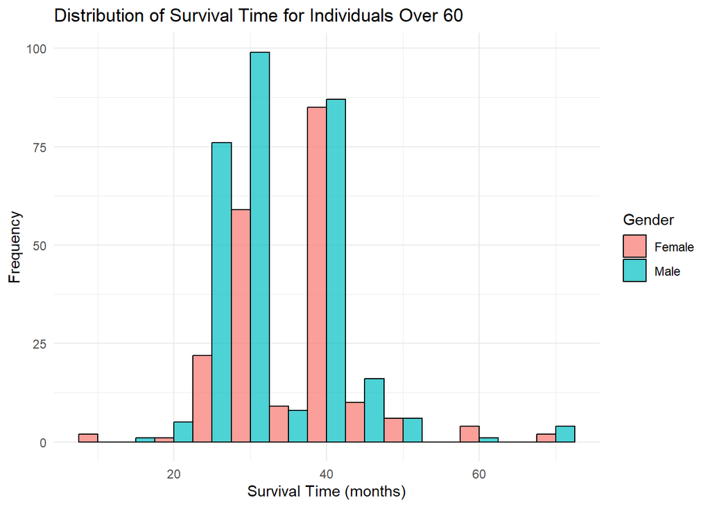

```r
over_60 <- data[data$Age > 60, ]
ggplot(data = over_60, aes(x = Survival.Time..months., fill = Gender)) +
  geom_histogram(binwidth = 5, position = "dodge", alpha = 0.7, color = "black") +
  labs(title = "Distribution of Survival Time for Individuals Over 60",
       x = "Survival Time (months)",
       y = "Frequency",
       fill = "Gender") +
  theme_minimal()
```

The histogram displays the distribution of survival time for individuals over 60 years old, separated by gender. It shows the frequency distribution of survival time in months, with males and females represented by different colors. The distribution appears skewed to the right but also appears bell shaped .Let’s try log transformation.

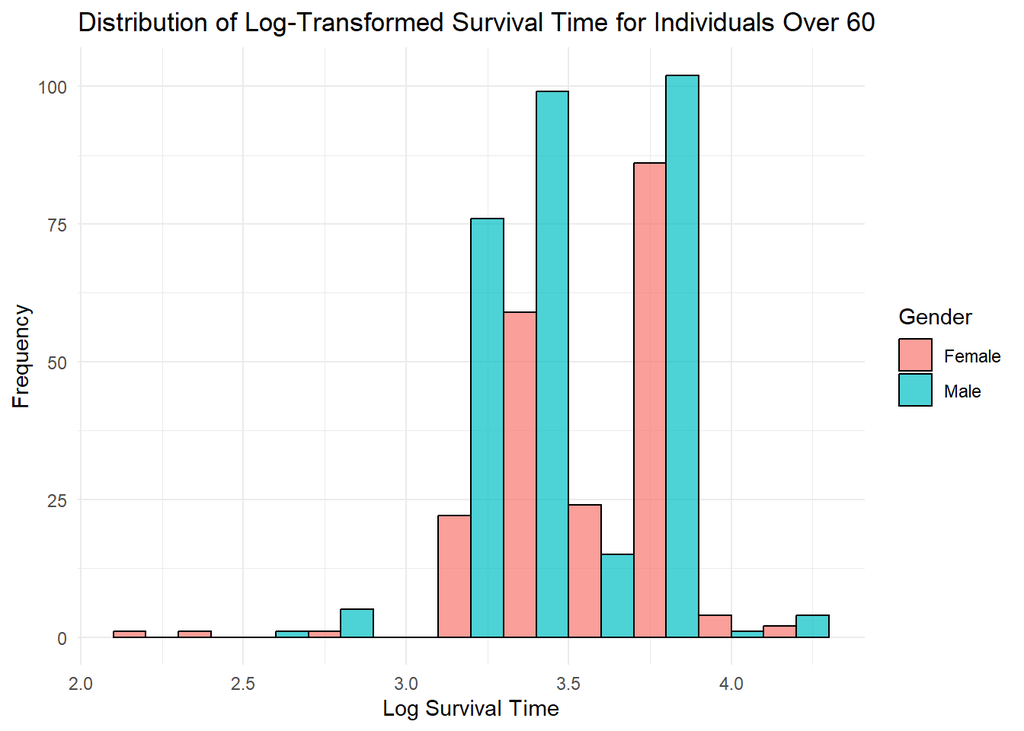

```r
over_60$log_Survival_Time <- log(over_60$Survival.Time..months.)

ggplot(data = over_60, aes(x = log_Survival_Time, fill = Gender)) +
  geom_histogram(binwidth = 0.2, position = "dodge", alpha = 0.7, color = "black") +
  labs(title = "Distribution of Log-Transformed Survival Time for Individuals Over 60",
       x = "Log Survival Time",
       y = "Frequency",
       fill = "Gender") +
  theme_minimal()
```

After applying a logarithmic transformation to the survival time data, the histogram demonstrates the distribution of log-transformed survival time for individuals over 60 years old, still separated by gender. The transformation appears to have reduced the skewness in the distribution, making it more symmetrical and allowing for easier comparison between genders. But still appear skewed(to left) due to the outliers.

## 6.(2p every item if not indicated) t-test (Welch t-test or Wilcoxon rank-sum test or Paired t-test)

### Implement a single t-test for one of your “normally or not-normally distributed” variable:

1. AIM

The aim is that to determine if there is a significant difference in the mean tumor grade between male and female patients.

2. HYPOTHESIS AND LEVEL OF SIGNIFICANCE

H0 : There is no significant difference in the mean tumor grade between male and female patients.

LEVEL OF SIGNIFICANCE (ALPHA) : 0.05

3. WHICH TEST YOU CHOOSE

Our data consists of two independent groups (males and females), we will use the Welch t-test. This test is chosen because it does not assume equal variances between the two groups.

4. ASSUMPTION CHECK

Check Normality

```r
male_normality <- shapiro.test(data$Tumor.Grade[data$Gender == "Male"])
female_normality <- shapiro.test(data$Tumor.Grade[data$Gender == "Female"])
male_normality
```

```
##
##  Shapiro-Wilk normality test
##
## data:  data$Tumor.Grade[data$Gender == "Male"]
## W = 0.79454, p-value < 2.2e-16
```

```r
female_normality
```

```
##
##  Shapiro-Wilk normality test
##
## data:  data$Tumor.Grade[data$Gender == "Female"]
## W = 0.78981, p-value < 2.2e-16
```

p-value of male : 2.2e-16 p-value of female : 2.2e-16

So we can easily say that , both male and female are not distributed normally. Because p-values are less than level of significance.

Outliers check

No need to check for outliers, because we already know that , tumor grades could be between 1-4.

5. RESULT

```r
t_test <- t.test(Tumor.Grade ~ Gender, data = data, var.equal = FALSE)
t_test
```

```
##
##  Welch Two Sample t-test
##
## data:  Tumor.Grade by Gender
## t = -4.4171, df = 1996.5, p-value = 1.054e-05
## alternative hypothesis: true difference in means between group Female and group Male is not equal to 0
## 95 percent confidence interval:
##  -0.3582160 -0.1379323
## sample estimates:
## mean in group Female   mean in group Male
##             2.309831             2.557905
```

Since the p-value (1.054e-05) is significantly less than the significance level of 0.05, we reject the null hypothesis. This indicates that there is a statistically significant difference in tumor grades between male and female patients.

6. CONCLUSION

Our analysis shows that male patients tend to have more severe tumors compared to female patients. This difference is statistically significant, meaning it is unlikely to be due to random chance.

7. What can be Type-1 and Type-2 error here? Not definition! Tell these situations in terms of your data. (4p) (2-3 sentences)

Type-1 Error : This would occur if we conclude that there is a significant difference in tumor grades between male and female patients when, in reality, there is no such difference.

Type-2 Error : This would occur if we conclude that there is no significant difference in tumor grades between male and female patients when, in reality, a difference does exist.

## 7.(2p every item if not indicated) ANOVA and Tukey Test

1. AIM

The aim is to compare the mean tumor grades among three or more different tumor types to determine if there is a statistically significant difference in tumor grades between these groups.

2. HYPOTHESIS AND LEVEL OF SIGNIFICANCE

H0 : The mean tumor grades are equal across all tumor types.

H1 : At least one tumor type has a mean tumor grade that is different from the others.

LEVEL OF SIGNIFICANCE (ALPHA) : 0.05

3. ASSUMPTION CHECK

Check normality

```r
set.seed(123)
data$Tumor.Grade <- sample(1:4, nrow(data), replace = TRUE)

grouped_data <- split(data$Tumor.Grade, data$Tumor.Type)

normalities <- lapply(grouped_data, function(x) {
  shapiro.test(x)
})

normalities
```

```
## $Astrocytoma
##
##  Shapiro-Wilk normality test
##
## data:  x
## W = 0.86308, p-value < 2.2e-16
##
##
## $Glioblastoma
##
##  Shapiro-Wilk normality test
##
## data:  x
## W = 0.85549, p-value < 2.2e-16
##
##
## $Meningioma
##
##  Shapiro-Wilk normality test
##
## data:  x
## W = 0.85354, p-value < 2.2e-16
```

All of the p-values are less than alpha, so they are not distributed normally.

Homogeneity of Variance check

```r
library(car)
leveneTest(Tumor.Grade ~ Tumor.Type, data = data)
```

```
## Levene's Test for Homogeneity of Variance (center = median)
##         Df F value Pr(>F)
## group    2  0.8986 0.4073
##       1997
```

The Levene’s Test results with a p-value of 0.4073 suggest no significant difference in variances between the groups, indicating homogeneity of variances.

4. RESULT OF ANOVA

```r
anova <- aov(Tumor.Grade ~ Tumor.Type, data = data)
summary(anova)
```

```
##               Df Sum Sq Mean Sq F value Pr(>F)
## Tumor.Type     2    0.6   0.276   0.223    0.8
## Residuals   1997 2469.1   1.236
```

Based on these results, we fail to reject the null hypothesis, indicating that there is no significant difference between the groups based on Tumor Type, as the p-value (0.8) is greater than the significance level (α = 0.05).

6. RESULT OF TUKEY

```r
tukey <- TukeyHSD(anova)
tukey
```

```
##   Tukey multiple comparisons of means
##     95% family-wise confidence level
##
## Fit: aov(formula = Tumor.Grade ~ Tumor.Type, data = data)
##
## $Tumor.Type
##                                 diff        lwr       upr     p adj
## Glioblastoma-Astrocytoma -0.04056630 -0.1858038 0.1046712 0.7894878
## Meningioma-Astrocytoma   -0.02685547 -0.1682629 0.1145520 0.8964255
## Meningioma-Glioblastoma   0.01371084 -0.1286187 0.1560404 0.9722507
```

According to the results of the Tukey multiple comparisons of means test with a 95% family-wise confidence level, there are no significant differences in tumor grades among any of the tumor types.

## 8.(2p every item) Multiple Linear Regression

1. AIM

The aim is that to utilize multiple linear regression to predict survival times of patients based on their age, gender, tumor types, tumor grades, and treatment outcomes.

2. VARIABLE SELECTION

```r
explanatory_variables <- c("Age", "Gender", "Tumor.Type", "Tumor.Grade", "Treatment.Outcome")
response_variable <- "Survival.Time..months."
```

We selected these variables because they are likely to affect survival time, while “Survival.Time..months.” was chosen as the variable to predict.

3. REGRESSION EQUATION

```r
regression_formula <- as.formula(paste(response_variable, "~", paste(explanatory_variables, collapse = " + ")))
regression_formula
```

```
## Survival.Time..months. ~ Age + Gender + Tumor.Type + Tumor.Grade +
##     Treatment.Outcome
```

4. HYPOTHESIS AND LEVEL OF SIGNIFICANCE (4P)

H0: There is no significant relationship between the explanatory variables (age, gender, tumor type, tumor grade, treatment outcome) and the survival time of patients.

H1 : There is a significant relationship between at least one of the explanatory variables and the survival time of patients.

LEVEL OF SIGNIFICANCE (ALPHA) : 0.05

5. FIND THE BEST MODEL

```r
best_model <- step(lm(regression_formula, data = data), direction = "both")
```

```
## Start:  AIC=8109.35
## Survival.Time..months. ~ Age + Gender + Tumor.Type + Tumor.Grade +
##     Treatment.Outcome
##
##                     Df Sum of Sq    RSS    AIC
## - Tumor.Grade        1       6.4 114306 8107.5
## - Age                1      24.9 114324 8107.8
## <none>                           114299 8109.3
## - Gender             1    2579.9 116879 8152.0
## - Tumor.Type         2   10017.1 124317 8273.4
## - Treatment.Outcome  3   19359.6 133659 8416.3
##
## Step:  AIC=8107.46
## Survival.Time..months. ~ Age + Gender + Tumor.Type + Treatment.Outcome
##
##                     Df Sum of Sq    RSS    AIC
## - Age                1      25.3 114331 8105.9
## <none>                           114306 8107.5
## + Tumor.Grade        1       6.4 114299 8109.3
## - Gender             1    2581.3 116887 8150.1
## - Tumor.Type         2   10015.6 124321 8271.4
## - Treatment.Outcome  3   19401.4 133707 8415.0
##
## Step:  AIC=8105.9
## Survival.Time..months. ~ Gender + Tumor.Type + Treatment.Outcome
##
##                     Df Sum of Sq    RSS    AIC
## <none>                           114331 8105.9
## + Age                1      25.3 114306 8107.5
## + Tumor.Grade        1       6.8 114324 8107.8
## - Gender             1    2711.9 117043 8150.8
## - Tumor.Type         2   10297.7 124629 8274.4
## - Treatment.Outcome  3   19377.7 133709 8413.0
```

6. ASSUMPTION CHECK

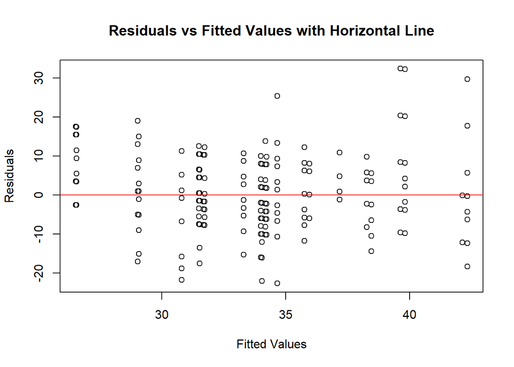

```r
plot(best_model$fitted.values, best_model$residuals,
     xlab = "Fitted Values", ylab = "Residuals",
     main = "Residuals vs Fitted Values with Horizontal Line")
abline(h = 0, col = "red")
```

```r
library(lmtest)
bptest(best_model)
```

```
##
##  studentized Breusch-Pagan test
##
## data:  best_model
## BP = 53.325, df = 6, p-value = 1.009e-09
```

The studentized Breusch-Pagan test yields a test statistic (BP) of 53.325 with 6 degrees of freedom and a very low p-value of 1.009e-09. This indicates strong evidence against the null hypothesis of homoscedasticity, suggesting the presence of heteroscedasticity in the residuals.

7. RESULT

```r
summary(best_model)
```

```
##
## Call:
## lm(formula = Survival.Time..months. ~ Gender + Tumor.Type + Treatment.Outcome,
##     data = data)
##
## Residuals:
##     Min      1Q  Median      3Q     Max
## -22.665  -5.721  -0.327   5.673  32.371
##
## Coefficients:
##                                      Estimate Std. Error t value Pr(>|t|)
## (Intercept)                           39.6293     0.5386  73.583  < 2e-16 ***
## GenderMale                             2.5062     0.3645   6.876 8.23e-12 ***
## Tumor.TypeGlioblastoma                -4.9644     0.4566 -10.872  < 2e-16 ***
## Tumor.TypeMeningioma                   0.1916     0.4637   0.413     0.68
## Treatment.OutcomePartial response     -3.8688     0.5452  -7.096 1.78e-12 ***
## Treatment.OutcomeProgressive disease  -8.0994     0.4987 -16.241  < 2e-16 ***
## Treatment.OutcomeStable disease       -8.1375     0.5209 -15.622  < 2e-16 ***
## ---
## Signif. codes:  0 '***' 0.001 '**' 0.01 '*' 0.05 '.' 0.1 ' ' 1
##
## Residual standard error: 7.574 on 1993 degrees of freedom
## Multiple R-squared:  0.2278, Adjusted R-squared:  0.2255
## F-statistic:    98 on 6 and 1993 DF,  p-value: < 2.2e-16
```

The output of the best model indicates a multiple linear regression analysis with significant predictors. Gender, Tumor Type (specifically Glioblastoma), and Treatment Outcome (specifically Progressive Disease and Stable Disease) all show statistically significant associations with the survival time of patients. The model has an adjusted R-squared value of 0.2255, indicating that approximately 22.55% of the variability in survival time can be explained by the predictors included in the model.

8. CONCLUSION